# EDA Correlation

Correlation matrix is a comprehensive overview of our feature space. It shows whether two features are connected so that one changes with a predictable trend if you change the other. The closer this coefficient is to zero the weaker is the correlation. Both 1 and -1 are the ideal cases of perfect correlation and anti-correlation.

1.Data load and preparation. For the purpose of this plot we will recode categorical features as integers.

```r
#
dataset <- read.csv('data/fdata_v1_trgencd.csv',stringsAsFactors = FALSE )
#spaces
dataset <- data.frame(lapply(dataset, trimws), stringsAsFactors = FALSE)

target <- 'hasclaim'
continuous <- c(
 'modelscore',
 'external_length_in',
 'external_width_in',
 'external_height_in',
 'external_vehicleage',
 'vehicleage',
 'ratingvalue',
 'estimatedannualdistance',
 'odometerreading',
 'daysperweekdriven',
 'driverage',
 'havelicenseage',
 'mvrstatusage',
 'garageterritory',
 'vehnumber',
 'drivernumber',
 'viol_pointschargedterm',
 'acci_pointschargedterm',
 'viol_driverpointsnumbercountterm',
 'acci_driverpointsnumbercountterm',
 'viol_infractioncdcountterm',
 'acci_infractioncdcountterm',
 'viol_last_infractionage',
 'acci_last_infractionage',
 'viol_last_convictionage',
 'acci_last_convictionage',
 'external_engine',
 'enginesize',
 'enginehorsepower',
 'external_make_encd',
 'external_model_encd',
 'manufacturer_encd',
 'model_encd',
 'registrationstateprovcd_encd',
 'vehbodytypecd_encd',
 'performancecd_encd',
 'restraintcd_encd',
 'antitheftcd_encd',
 'enginecylinders_encd',
 'vehusecd_encd',
 'classcd_encd',
 'carpoolind_encd',
 'daylightrunninglightsind_encd',
 'passiveseatbeltind_encd',
 'programtypecd_encd',
 'driverstatuscd_encd',
 'licensedstateprovcd_encd',
 'relationshiptoinsuredcd_encd',
 'scholasticdiscountind_encd',
 'mvrstatus_encd',
 'maturedriverind_encd',
 'drivertrainingind_encd',
 'gooddriverind_encd',
 'accidentpreventioncourseind_encd',
 'persontypecd_encd',
 'gendercd_encd',
 'maritalstatuscd_encd',
 'occupationclasscd_encd')


dataset[continuous] <- sapply(dataset[continuous], as.numeric)
```

2. Libraries

```r
library(dplyr)
```

```r
library(corrplot)
```

3. Correlation matrix

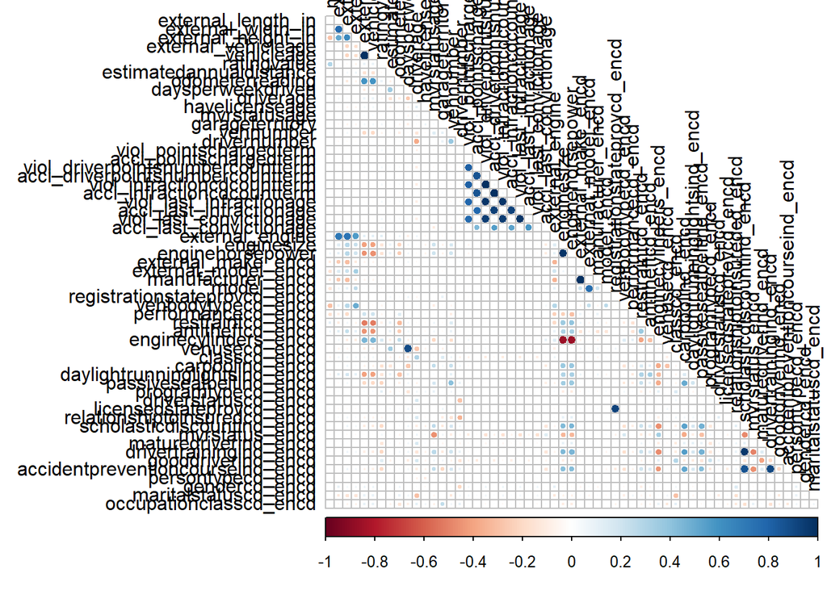

```r
dataset[continuous] %>%
  cor(use="complete.obs", method = "spearman") %>%
  corrplot(type="lower", tl.col = "black",  diag=FALSE)
```

In this kind of plot we want to look for the bright, large circles which immediately show the strong correlations (size and shading depends on the absolute values of the coefficients; colour depends on direction). Anything that you would have to squint to see is usually not worth seeing.

4. Let’s reduce the set of features to most correlated and our plot will be easier to read and more informative.

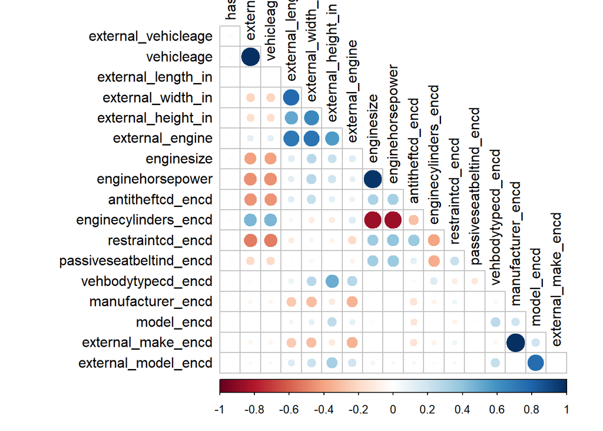

```r
v_set <- c(
 'hasclaim',
 'external_vehicleage',
 'vehicleage',
 'external_length_in',
 'external_width_in',
 'external_height_in',
 'external_engine',
 'enginesize',
 'enginehorsepower',
 'antitheftcd_encd',
 'enginecylinders_encd',
 'restraintcd_encd',
 'passiveseatbeltind_encd',
 'vehbodytypecd_encd',
 'manufacturer_encd',
 'model_encd',
 'external_make_encd',
 'external_model_encd'
 )
dataset[v_set] <- sapply(dataset[v_set], as.numeric)
dataset[v_set] %>%
  cor(use="complete.obs", method = "spearman") %>%
  corrplot(type="lower", tl.col = "black",  diag=FALSE)
```

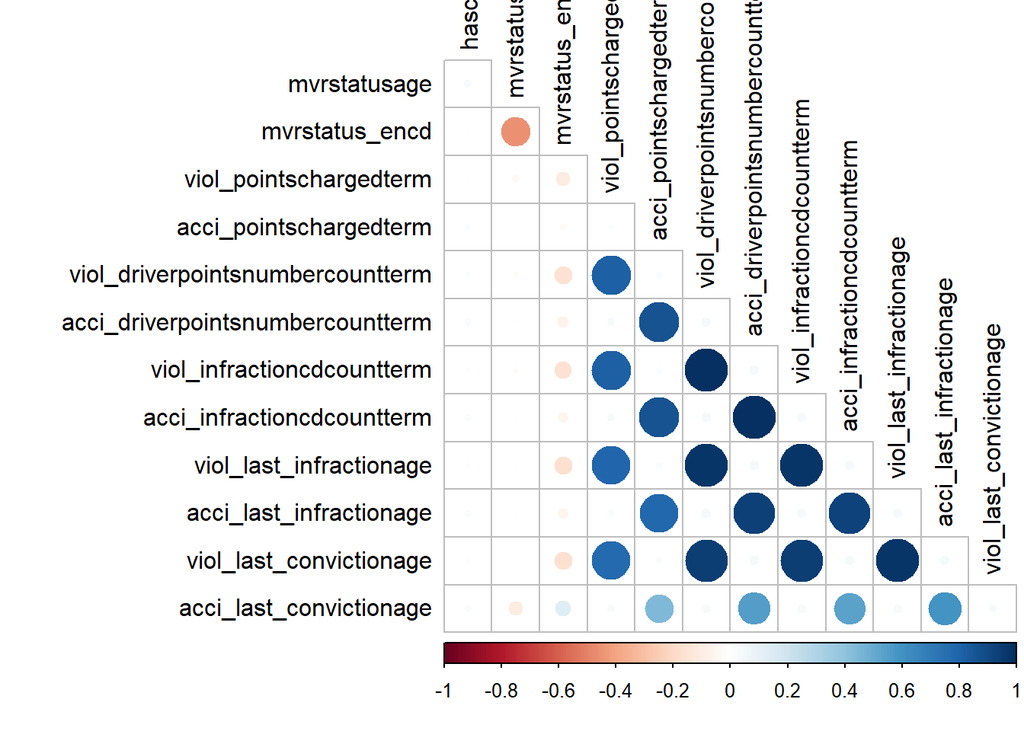

```r
mvr_set <- c(
 'hasclaim',
 'mvrstatusage',
 'mvrstatus_encd',
 'viol_pointschargedterm',
 'acci_pointschargedterm',
 'viol_driverpointsnumbercountterm',
 'acci_driverpointsnumbercountterm',
 'viol_infractioncdcountterm',
 'acci_infractioncdcountterm',
 'viol_last_infractionage',
 'acci_last_infractionage',
 'viol_last_convictionage',
 'acci_last_convictionage')
dataset[mvr_set] <- sapply(dataset[mvr_set], as.numeric)
dataset[mvr_set] %>%
  cor(use="complete.obs", method = "spearman") %>%
  corrplot(type="lower", tl.col = "black",  diag=FALSE)
```

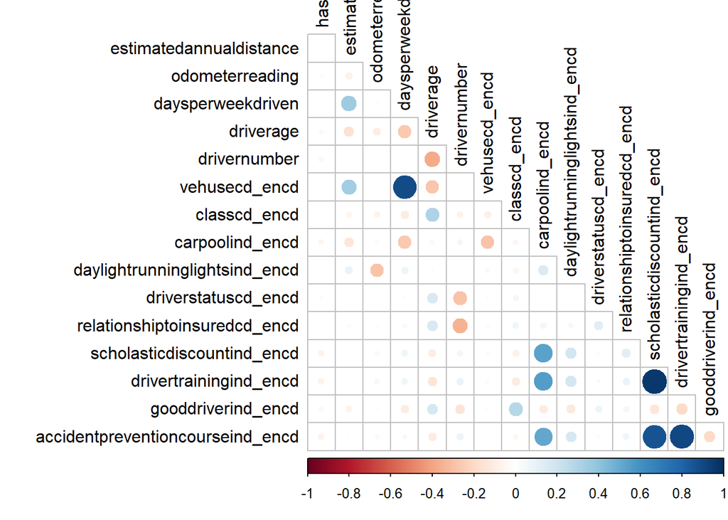

```r
o_set <- c(
 'hasclaim',
 'estimatedannualdistance',
 'odometerreading',
 'daysperweekdriven',
 'driverage',
 'drivernumber',
 'vehusecd_encd',
 'classcd_encd',
 'carpoolind_encd',
 'daylightrunninglightsind_encd',
 'driverstatuscd_encd',
 'relationshiptoinsuredcd_encd',
 'scholasticdiscountind_encd',
 'drivertrainingind_encd',
 'gooddriverind_encd',
 'accidentpreventioncourseind_encd')
dataset[o_set] <- sapply(dataset[o_set], as.numeric)
dataset[o_set] %>%
  cor(use="complete.obs", method = "spearman") %>%
  corrplot(type="lower", tl.col = "black",  diag=FALSE)
```